# Summary

## What we observed from marriage rate:

*The general trend:*

*Relationship to gender, race, education level, region and age:*

Like stated above, marriage has been declining since 1960 across every factor. Though, marriage rate of African-American is increasing from around 2012, which is very rare. Keeping all other factors constant, for both genders, white people usually has the highest marriage rate, then are Hispanics, and African-American people have the lowest marriage. People who have higher education level usually are more unlikely to get married, but surprisingly, since around 1990, marriage rate of people who have high school diploma dropped, and became the lowest now. Dividing it by region; people who live in the mountain west area have the highest marriage rate, and people who live in Mid-Atlantic have the lowest rate. People who are older are more likely to get married than younger people.

## What we observed from divorce rate:

*The general trend:*

For divorce rate, the data set only has several factors from the list we listed on the home page. Divorce data set only contains sex, age, education level and wealth. For all people (35-44), the data shows that divorce has been increasing over time. From 1970 to 1990, the divorce rate raised very quickly (which also matches the time period when marriage rate declined very quickly), then it got significantly slower after 1990. From around 2005 to 2006, it speeded up again.

*Relationship to age, education level, and wealth:*

In general, people who are 45-54 has a higher divorce rate than people who are 35-44. Looking into the factors education and wealth. People who have higher education level and who are richer have lower divorce rate. Interestingly, people who went to/ did not finish college have a lower divorce rate than people who went to some college and is contrary from what we observed about education and divorce rate.

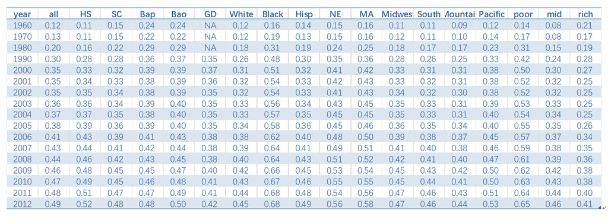